# Capstone Quiz I

Complete all **Exercises**, and submit answers to **Questions** on the Coursera platform.

This initial quiz will concern exploratory data analysis (EDA) of the Ames Housing dataset. EDA is essential when working with any source of data and helps inform modeling.

First, let us load the data:

```r
setwd("~/coursera/statistics/capstone/week2/")
load("ames_train.Rdata")
```

```r
library(dplyr)
```

```r
library(ggplot2)
library(GGally)
library(statsr)
```

1. Which of the following are the three variables with the highest number of missing observations?
   1. `Misc.Feature`, `Fence`, `Pool.QC`
   2. ** `Misc.Feature`, `Alley`, `Pool.QC` **
   3. `Pool.QC`, `Alley`, `Fence`
   4. `Fireplace.Qu`, `Pool.QC`, `Lot.Frontage`

```r
# type your code for Question 1 here, and Knit

ames_train %>%
  select(Misc.Feature, Fence, Pool.QC, Alley, Fireplace.Qu, Lot.Frontage) %>%
  mutate(Misc.Feature_1 = ifelse(is.na(Misc.Feature),1,0),
         Fence_1        = ifelse(is.na(Fence),1,0),
         Pool.QC_1      = ifelse(is.na(Pool.QC),1,0),
         Alley_1        = ifelse(is.na(Alley),1,0),
         Fireplace.Qu_1 = ifelse(is.na(Fireplace.Qu),1,0),
         Lot.Frontage_1 = ifelse(is.na(Lot.Frontage),1,0)) %>%
  select(Misc.Feature_1, Fence_1, Pool.QC_1, Alley_1, Fireplace.Qu_1, Lot.Frontage_1) %>%
  as.data.frame() %>%
  as.matrix() %>%
  colSums()
```

```
## Misc.Feature_1        Fence_1      Pool.QC_1        Alley_1 Fireplace.Qu_1
##            971            798            997            933            491
## Lot.Frontage_1
##            167
```

2. How many categorical variables are coded in R as having type `int`? Change them to factors when conducting your analysis.
   1. 0
   2. 1
   3. ** 2 **
   4. 3

```r
# type your code for Question 2 here, and Knit
str(ames_train)
```

```
## Classes 'tbl_df', 'tbl' and 'data.frame':    1000 obs. of  81 variables:
##  $ PID            : int  909176150 905476230 911128020 535377150 534177230 908128060 902135020 528228540 923426010 908186050 ...
##  $ area           : int  856 1049 1001 1039 1665 1922 936 1246 889 1072 ...
##  $ price          : int  126000 139500 124900 114000 227000 198500 93000 187687 137500 140000 ...
##  $ MS.SubClass    : int  30 120 30 70 60 85 20 20 20 180 ...
##  $ MS.Zoning      : Factor w/ 7 levels "A (agr)","C (all)",..: 6 6 2 6 6 6 7 6 6 7 ...
##  $ Lot.Frontage   : int  NA 42 60 80 70 64 60 53 74 35 ...
##  $ Lot.Area       : int  7890 4235 6060 8146 8400 7301 6000 3710 12395 3675 ...
##  $ Street         : Factor w/ 2 levels "Grvl","Pave": 2 2 2 2 2 2 2 2 2 2 ...
##  $ Alley          : Factor w/ 2 levels "Grvl","Pave": NA NA NA NA NA NA 2 NA NA NA ...
##  $ Lot.Shape      : Factor w/ 4 levels "IR1","IR2","IR3",..: 4 4 4 4 4 4 4 4 4 4 ...
##  $ Land.Contour   : Factor w/ 4 levels "Bnk","HLS","Low",..: 4 4 4 4 4 4 1 4 4 4 ...
##  $ Utilities      : Factor w/ 3 levels "AllPub","NoSeWa",..: 1 1 1 1 1 1 1 1 1 1 ...
##  $ Lot.Config     : Factor w/ 5 levels "Corner","CulDSac",..: 1 5 5 1 5 1 5 5 1 5 ...
##  $ Land.Slope     : Factor w/ 3 levels "Gtl","Mod","Sev": 1 1 1 1 1 1 2 1 1 1 ...
```

[output cut: 67 more lines]

```r
#Mo.Sold
levels(factor(ames_train$Mo.Sold))
```

```
##  [1] "1"  "2"  "3"  "4"  "5"  "6"  "7"  "8"  "9"  "10" "11" "12"
```

```r
#Yr.Sold
levels(factor(ames_train$Yr.Sold))
```

```
## [1] "2006" "2007" "2008" "2009" "2010"
```

3. In terms of price, which neighborhood has the highest standard deviation?
   1. **`StoneBr`**
   2. `Timber`
   3. `Veenker`
   4. `NridgHt`

```r
# type your code for Question 3 here, and Knit

ames_train %>%
  filter(Neighborhood %in% c('StoneBr', 'Timber', 'Veenker', 'NridgHt' )) %>%
  select(Neighborhood, price) %>%
  group_by(Neighborhood) %>%
  summarise(a = sd(price))
```

```
## # A tibble: 4 × 2
##   Neighborhood         a
##         <fctr>     <dbl>
## 1      NridgHt 105088.90
## 2      StoneBr 123459.10
## 3       Timber  84029.57
## 4      Veenker  72545.41
```

4. Using scatter plots or other graphical displays, which of the following variables appears to be the best single predictor of `price`?
   1. `Lot.Area`
   2. `Bedroom.AbvGr`
   3. **`Overall.Qual`**
   4. `Year.Built`

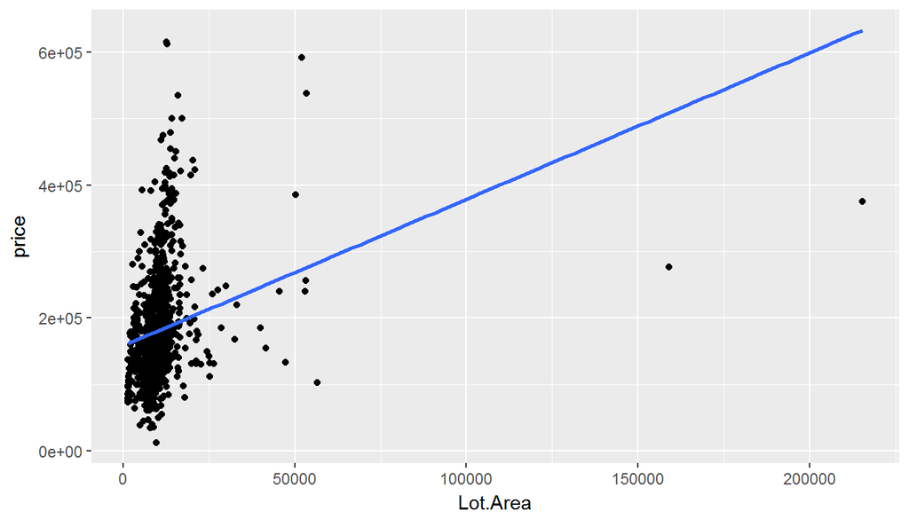

```r
# type your code for Question 4 here, and Knit

ggplot(ames_train, aes(y = price, x = Lot.Area)) +
  geom_point() +
      geom_smooth(method=lm,   # Add linear regression lines
                se=FALSE,    # Don't add shaded confidence region
                fullrange=TRUE) # Extend regression lines
```

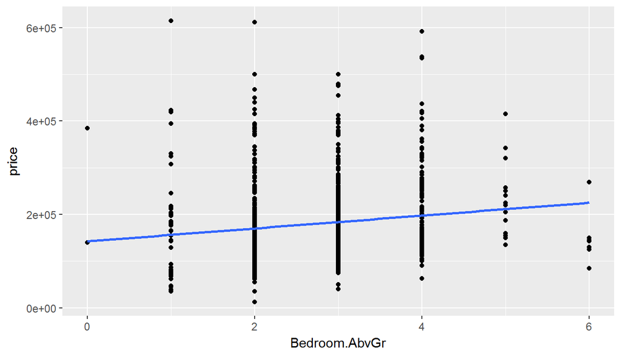

```r
ggplot(ames_train, aes(x =  Bedroom.AbvGr, y = price)) +
  geom_point()+
      geom_smooth(method=lm,   # Add linear regression lines
                se=FALSE,    # Don't add shaded confidence region
                fullrange=TRUE) # Extend regression lines
```

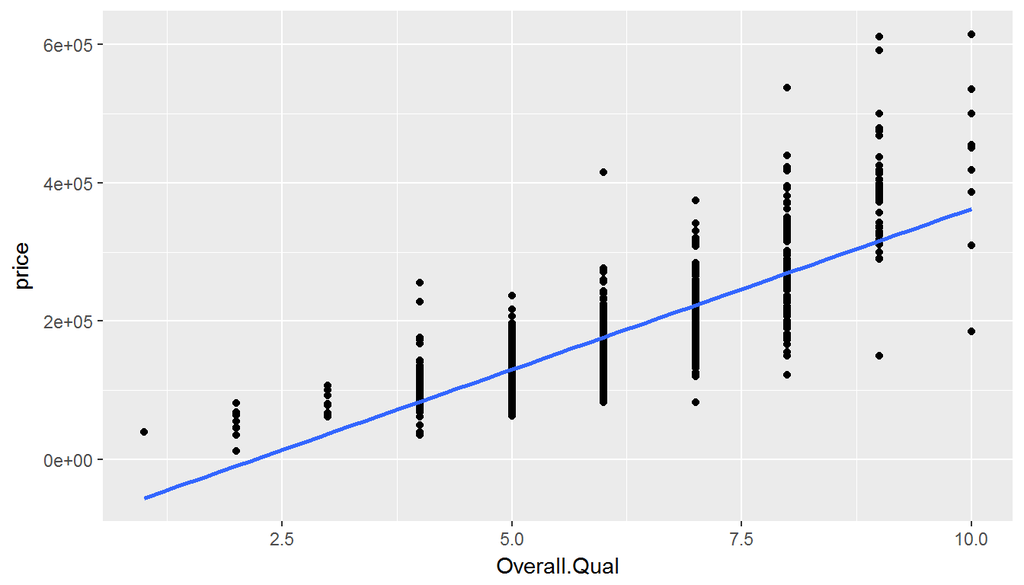

```r
ggplot(ames_train, aes(x = Overall.Qual, y = price)) +
  geom_point() +
      geom_smooth(method=lm,   # Add linear regression lines
                se=FALSE,    # Don't add shaded confidence region
                fullrange=TRUE) # Extend regression lines
```

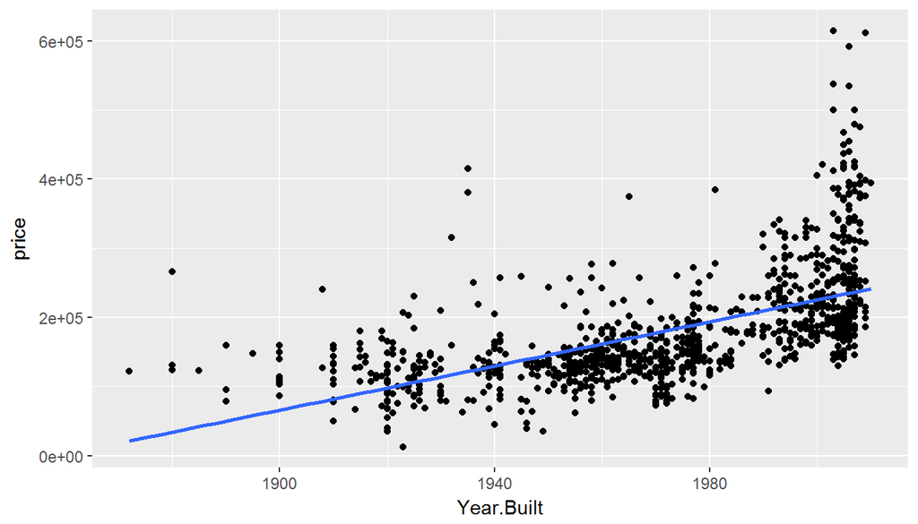

```r
ggplot(ames_train, aes(x = Year.Built, y = price)) +
  geom_point()+
      geom_smooth(method=lm,   # Add linear regression lines
                se=FALSE,    # Don't add shaded confidence region
                fullrange=TRUE) # Extend regression lines
```

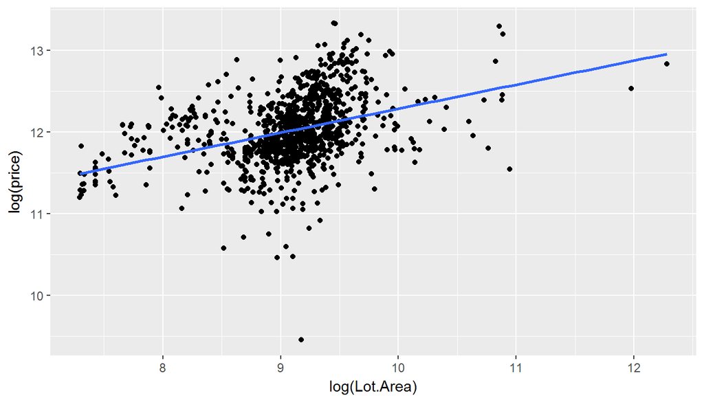

```r
# type your code for Question 5 here, and Knit

ggplot(ames_train, aes(x = log(Lot.Area), y = log(price))) +
  geom_point() +
      geom_smooth(method=lm,   # Add linear regression lines
                se=FALSE,    # Don't add shaded confidence region
                fullrange=TRUE) # Extend regression lines
```

6. Suppose that your prior for the proportion of houses that have at least one garage is Beta(9, 1). What is your posterior? Assume a beta-binomial model for this proportion.
   1. Beta(954, 46)
   2. Beta(963, 46)
   3. Beta(954, 47)
   4. Beta(963, 47)

```r
# type your code for Question 6 here, and Knit
```

7. Which of the following statements is true about the dataset?
   1. Over 30 percent of houses were built after the year 1999.
   2. The median housing price is greater than the mean housing price.
   3. **21 houses do not have a basement.**
   4. 4 houses are located on gravel streets.

```r
# type your code for Question 7 here, and Knit
#Over 30 percent of houses were built after the year 1999.
(
  ames_train %>%
  filter(Year.Built > 1999) %>%
  nrow() /
  ames_train %>%
  nrow()
) * 100
```

```
## [1] 27.2
```

```r
#NO! 27,2

#The median housing price is greater than the mean housing price.
ames_train %>%
  select(price) %>%
  summarise(mean = mean(price), median = median(price)) %>%
  mutate(resp = median > mean)
```

```
## # A tibble: 1 × 3
##       mean median  resp
##      <dbl>  <dbl> <lgl>
## 1 181190.1 159467 FALSE
```

```r
#NO!

#21 houses do not have a basement.
ames_train %>%
  select(Total.Bsmt.SF) %>%
  filter(Total.Bsmt.SF == 0) %>%
  nrow()
```

```
## [1] 21
```

```r
#YES!

#4 houses are located on gravel streets.
ames_train %>%
  select(Street) %>%
  group_by(Street) %>%
  summarise(c = n())
```

```
## # A tibble: 2 × 2
##   Street     c
##   <fctr> <int>
## 1   Grvl     3
## 2   Pave   997
```

```r
#NO!
```

8. Test, at the $\alpha = 0.05$ level, whether homes with a garage have larger square footage than those without a garage.
   1. **With a p-value near 0.000, we reject the null hypothesis of no difference.**
   2. With a p-value of approximately 0.032, we reject the null hypothesis of no difference.
   3. With a p-value of approximately 0.135, we fail to reject the null hypothesis of no difference.
   4. With a p-value of approximately 0.343, we fail to reject the null hypothesis of no difference.

```r
# type your code for Question 8 here, and Knit

data <- ames_train %>%
  select(area, Garage.Area) %>%
  filter(!is.na(Garage.Area), !is.na(area)) %>%
  mutate(hasGarage = factor(ifelse(Garage.Area > 0, "yes", "no")))

inference(data, x = hasGarage, y = area, type = "ht", statistic = "mean", method = "simulation", alternative = "twosided")
```

```
## Response variable: numerical
## Explanatory variable: categorical (2 levels)
## n_no = 46, y_bar_no = 1145.0435, s_no = 555.5
## n_yes = 953, y_bar_yes = 1492.2508, s_yes = 645
## H0: mu_no =  mu_yes
## HA: mu_no != mu_yes
## p_value = < 0.0001
```

[figure not shown]

9. For homes with square footage greater than 2000, assume that the number of bedrooms above ground follows a Poisson distribution with rate $\lambda$. Your prior on $\lambda$ follows a Gamma distribution with mean 3 and standard deviation 1. What is your posterior mean and standard deviation for the average number of bedrooms in houses with square footage greater than 2000 square feet?
   1. Mean: 3.61, SD: 0.11
   2. Mean: 3.62, SD: 0.16
   3. Mean: 3.63, SD: 0.09
   4. Mean: 3.63, SD: 0.91

```r
# type your code for Question 9 here, and Knit
```

10. When regressing $\log$(`price`) on $\log$(`area`), there are some outliers. Which of the following do the three most outlying points have in common?
    1. **They had abnormal sale conditions.**
    2. They have only two bedrooms.
    3. They have an overall quality of less than 3.
    4. They were built before 1930.

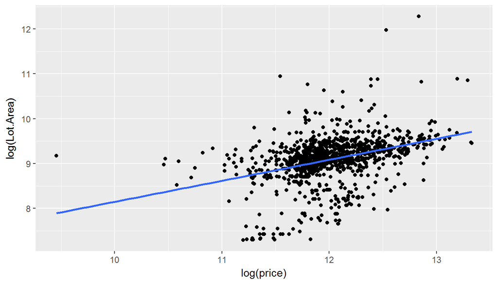

```r
# type your code for Question 10 here, and Knit

ggplot(ames_train, aes(y = log(Lot.Area), x = log(price))) +
  geom_point() +
      geom_smooth(method=lm,   # Add linear regression lines
                se=FALSE,    # Don't add shaded confidence region
                fullrange=TRUE) # Extend regression lines
```

```r
model = lm(data = ames_train, formula = log(price) ~ log(Lot.Area))

a <- model$residuals ^2

b <- a %>%
  sort(decreasing = TRUE) %>%
  head(., n =3) %>%
  names()
b
```

```
## [1] "428" "645" "559"
```

```r
View(ames_train[c(428, 645, 559),])
```

11. Which of the following are reasons to log-transform `price` if used as a dependent variable in a linear regression?
    1. **`price` is right-skewed.**
    2. `price` cannot take on negative values.
    3. `price` can only take on integer values.
    4. Both a and b.

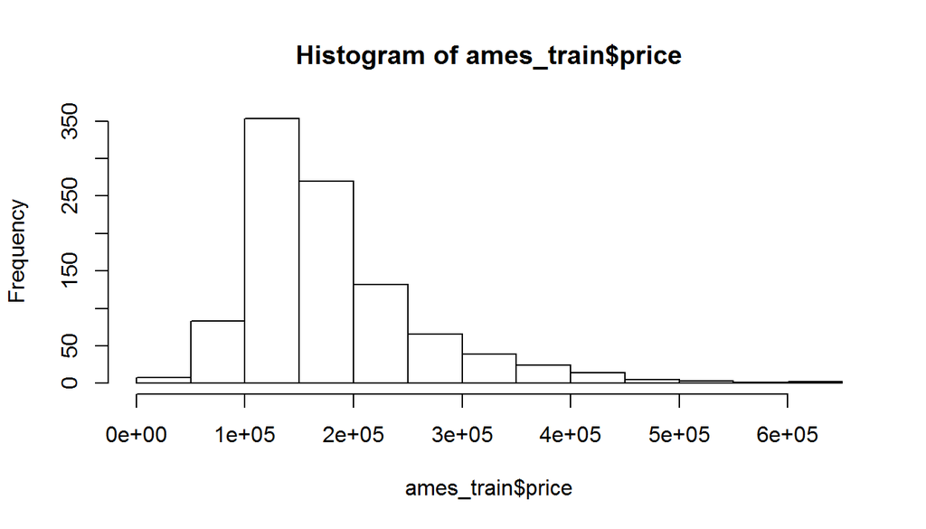

```r
# type your code for Question 11 here, and Knit
hist(ames_train$price)
```

12. How many neighborhoods consist of only single-family homes? (e.g. `Bldg.Type` = `1Fam`)
    1. 0
    2. 1
    3. 2
    4. **3**

```r
# type your code for Question 12 here, and Knit
ames_train %>%
  select(Neighborhood, Bldg.Type) %>%
  group_by(Neighborhood) %>%
  summarise(a = mean(Bldg.Type == "1Fam")) %>%
  filter(a == 1)
```

```
## # A tibble: 3 × 2
##   Neighborhood     a
##         <fctr> <dbl>
## 1      ClearCr     1
## 2      NoRidge     1
## 3       Timber     1
```

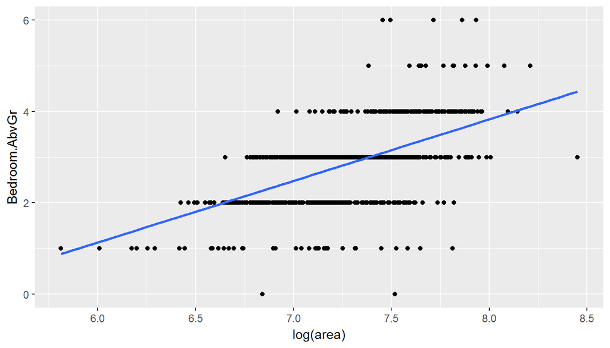

```r
# type your code for Question 13 here, and Knit

ggplot(ames_train, aes(x = log(area), y = Bedroom.AbvGr)) +
  geom_point() +
      geom_smooth(method=lm,   # Add linear regression lines
                se=FALSE,    # Don't add shaded confidence region
                fullrange=TRUE) # Extend regression lines
```

14. Of the people who have unfinished basements, what is the average square footage of the unfinished basement?
    1. 590.36
    2. 595.27
    3. 614.37
    4. 681.94

```r
# type your code for Question 14 here, and Knit
ames_train %>%
  filter(!is.na(Bsmt.Unf.SF)) %>%
  summarise(mean=mean(Bsmt.Unf.SF))
```

```
## # A tibble: 1 × 1
##      mean
##     <dbl>
## 1 546.989
```